# The Gender Wage Gap: A Myth or Statiscal Truth?

### Libraries used

```r
library(readxl)
library(ggplot2)
library(purrr)
library(tidyverse)
library(scales)
library(dplyr)
```

## Summary

This project investigates whether a gender wage gap exists among individuals aged 25 to 64 with a bachelor’s degree or higher, using 2022 median annual earnings data from the U.S. Census Bureau. After cleaning the dataset, the analysis compared men’s and women’s median earnings across all degree majors and field categories. Descriptive statistics, histograms, boxplots, and category-level comparisons all showed that women earn less than men in every major represented. On average, women earn $67,651 compared to $86,022 for men—about 79% of men’s earnings—demonstrating a clear and measurable gender wage gap.

Higher-paying disciplines such as *Science & Engineering* and *Business* show the largest wage gaps, while lower-paying fields like *Education* and *Arts/Humanities/Other* display smaller but still persistent disparities. A correlation of –0.56 between total earnings and the wage gap confirms that disparities increase as the salary level of a major rises. The dataset has limitations, including lack of information on work experience, hours worked, and whether individuals work in their field; yet, the evidence strongly indicates that a gender wage gap exists in 2022. These results provides a picture of the wage inequality at that time, while acknowledging that trends may have shifted since.

## Purpose

The goal of this project is to determine whether a gender wage gap exists across fields of bachelor’s degree and whether pay level relates to the size of this gap. Using U.S. Census earnings data from 2022, this analysis compares men’s and women’s median annual earnings by field of study and tests whether higher or lower paying fields show more wage inequality.

## Data

The dataset used for this project is titled “Median Annual Earnings for Field of Bachelor’s Degree for First Major by Sex in 2022,” was collected and published by the U.S. Census Bureau (2022).It contains median annual earnings estimates for adults aged 25 to 64 whose highest level of education is a bachelor’s degree or higher. The data is organized into a table with the following major columns: *Field of Degree*, *Total Population*, *Men*, *Women*, and *Women’s Earnings as a Percentage of Men’s Earnings*. Overall the original data had 44 rows by 9 columns.

The Field of Degree column includes four subrows that group related degree types. The four main field categories are:

- *Science and Engineering Degrees*
- *Business Degrees*
- *Education Degrees*
- *Arts, Humanities, and Other Degrees*

These section headers serve as section headers and aren’t actual observations. Aside from the category name, the remaining columns in these rows contain empty cells or NA values. All actual data observations appear below these headings, showing specific degree majors within each category.

Under *Science and Engineering Degrees*, the dataset includes the following majors: Computer Science, Engineering, Civil Engineering, Electrical Engineering, Mechanical Engineering, Mathematics, Biology, Chemistry, Psychology, Economics,Political Science, Sociology, Nursing, and Other Science and Engineering Degrees. Under *Business Degrees*, the dataset lists: General Business, Accounting, Business Management & Administration, Marketing, Finance, and Other Business Degrees. Under *Education Degrees*, the dataset lists General Education, Elementary Education, and Other Education Degrees. Finally, under *Arts, Humanities, and Other Degrees*, the majors include: Communications, English Literature & Languages, Liberal Arts, History, Fine Arts, Commercial Art & Graphic Design, Family & Consumer Sciences, Physical Fitness/Parks/Recreation/Leisure, Criminal Justice and Fire Protection, Social Work, and Other Degrees.

Under the remaining major columns Total Population, Men, Women each contain two subcolumns: Estimate and MOE. The Estimate subcolumn reports the median annual earnings for that group in U.S. dollars. The corresponding MOE value (Margin of Error) quantifies the uncertainty of the estimate, indicating how much the sample value may differ from the true population value. The final major column, Women’s Earnings as a Percentage of Men’s Earnings, also contains an Estimate and MOE pair. In this case, the estimate represents the percentage of men’s median earnings that women earn for a given degree, and its margin of error reflects sampling uncertainty in percentage units rather than dollars.

### Data Cleaning

The dataset contained empty header rows and subrows from the original Excel formatting, which created NA values when imported. These were removed by using skip = 4 in read_excel(), from the readxl library, to bypass non-data rows. The columns were cleaned and standardized by manually renaming them using colnames(df_1) <- c(…) so that only valid variables with complete data were included in the analysis.

The only other missing or NA values in the dataset appeared in the category header rows (the subrows under each Field of Degree). These rows did not contain actual observations, so they were removed entirely during data cleaning to ensure that only valid degree majors remained in the analysis. Additionally, the descriptive footer rows at the bottom of the spreadsheet contained Census notes, source information, and disclosure statements. Those were also removed, as they did not contain any usable observations or numerical data for analysis.

## Exploratory Data Analysis

### Overall Trends

```r
summary(df_1[, c("Total_Est", "Men_Est", "Women_Est", "WM_Gap")])
```

```
   Total_Est         Men_Est         Women_Est          WM_Gap
 Min.   : 52850   Min.   : 60090   Min.   : 49530   Min.   :-27140
 1st Qu.: 61710   1st Qu.: 70543   1st Qu.: 55635   1st Qu.:-23435
 Median : 75765   Median : 88255   Median : 64515   Median :-18075
 Mean   : 76839   Mean   : 86022   Mean   : 67651   Mean   :-18371
 3rd Qu.: 86515   3rd Qu.: 99763   3rd Qu.: 76858   3rd Qu.:-14242
 Max.   :121600   Max.   :123800   Max.   :105200   Max.   : -5710
```

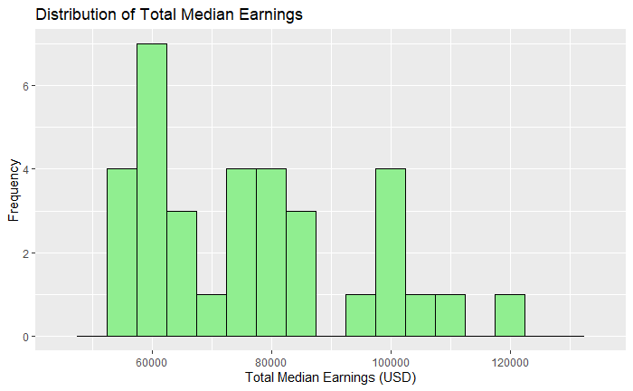

```r
# Set consistent x-axis range for all plots:
xmin <- 45000
xmax <- 135000

ggplot(df_1, aes(x = Total_Est)) +
  geom_histogram(binwidth = 5000, fill = "lightgreen", color = "black") +
  scale_x_continuous(limits = c(xmin, xmax)) +
  labs(title = "Distribution of Total Median Earnings",
       x = "Total Median Earnings (USD)", y = "Frequency")
```

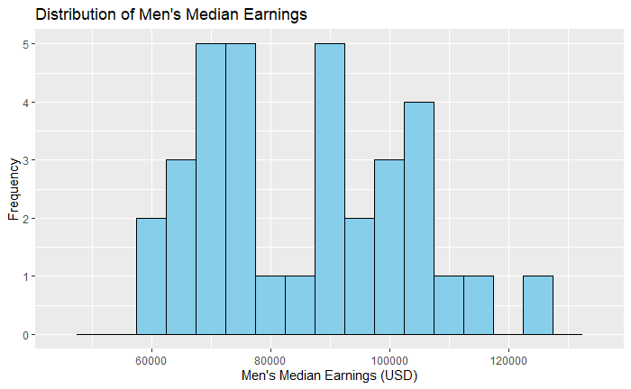

```r
ggplot(df_1, aes(x = Men_Est)) +
  geom_histogram(binwidth = 5000, fill = "skyblue", color = "black") +
  scale_x_continuous(limits = c(xmin, xmax)) +
  labs(title = "Distribution of Men's Median Earnings",
       x = "Men's Median Earnings (USD)", y = "Frequency")
```

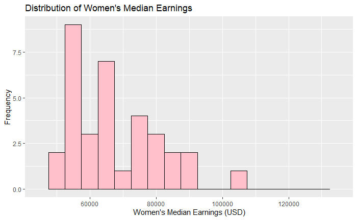

```r
ggplot(df_1, aes(x = Women_Est)) +
  geom_histogram(binwidth = 5000, fill = "pink", color = "black") +
  scale_x_continuous(limits = c(xmin, xmax)) +
  labs(title = "Distribution of Women's Median Earnings",
       x = "Women's Median Earnings (USD)", y = "Frequency")
```

The histograms for total median earnings, men’s earnings, and women’s earnings span a similar income range, generally between approximately $55,000 and $120,000, but the centers and spreads differ significantly by gender.

However the histograms spread does not resemble either women’s or men’s earnings. It does not necessarily combine both gender groups, rather it is representative of the entire population regardless of gender.

Women appear in lower wage ranges compared to men and total population, demonstrating reduced representation in the higher paying degree categories.

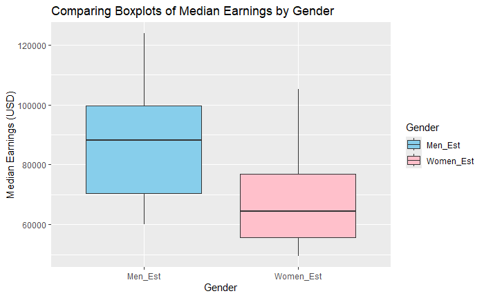

```r
box_plots <- df_1 %>%
  select(Men_Est, Women_Est) %>%
  tidyr::pivot_longer(cols = everything(), names_to = "Gender", values_to = "Earnings")

ggplot(box_plots, aes(x = Gender, y = Earnings, fill = Gender)) +
  geom_boxplot() +
  labs(title = "Comparing Boxplots of Median Earnings by Gender", x = "Gender",
       y = "Median Earnings (USD)") +
  scale_fill_manual(values = c("Men_Est" = "skyblue", "Women_Est" = "pink"))
```

The *Comparing Boxplots of Median Earnings by Gender* supports the patterns observed in the histograms. It also provides a more concise summary of the quartile range, and spread for each both genders. The median line for men’s estimated earnings is visibly much higher than that of women’s median earnings. This is also true for the quartile range visualized meaning that about typical (50%) earnings for men exceed those for women. Furthermore, the boxplot for men extends into higher minimum and maximum values than that for women.

Overall, the boxplots clearly match the conclusions suggested by the histograms: * Men have relatively higher medians, higher upper quartiles, and greater presence in the highest-paying fields. * * Women have lower medians, lower quartiles, and lower occupation in top-earning fields.

### Field Trends

```r
df_1 %>%
  arrange(WM_Gap) %>%
  select(`Bachelor's Degree`, Men_Est, Women_Est, WM_Gap) %>%
  head(10)
```

| Bachelor's Degree | Men_Est | Women_Est | WM_Gap |
| --- | --- | --- | --- |
| Engineering | 103300 | 76160 | -27140 |
| Other Science and Engineering Degrees1 | 92050 | 65150 | -26900 |
| Finance | 106400 | 79940 | -26460 |
| Other Business Degrees | 91000 | 64900 | -26100 |
| Mathmatics | 99050 | 73500 | -25550 |
| Accounting | 100000 | 75010 | -24990 |
| Biology | 96620 | 72200 | -24420 |
| Computer Science | 115500 | 91990 | -23510 |
| Business Management and Adminstration | 87090 | 63640 | -23450 |
| General Business | 90080 | 66690 | -23390 |

Above is a table of the 10 bachelor’s degrees with the greatest absolute difference in pay between men’s and women’s annual salary.In every one of these majors, the difference between men’s and women’s median earnings exceeds $23,000, with the highest gap at $27,140 in Engineering. These degrees not only generate some of the highest overall salaries, suggesting that the wage gap is not uniform across majors but expands notably in more lucrative disciplines. Upon reviewing the categories each degree falls one may note the evenly dominating fields are *Business* and *Science and Engineering Field*. This indicates that women in these fields may face under representation, pay disadvantages relative to their male counterparts or both.

```r
df_1 %>%
  arrange(desc(WM_Gap)) %>%
  select(`Bachelor's Degree`, Men_Est, Women_Est, WM_Gap) %>%
  head(10)
```

| Bachelor's Degree | Men_Est | Women_Est | WM_Gap |
| --- | --- | --- | --- |
| Social Work | 60090 | 54380 | -5710 |
| Physical Fitness, Parks, Recreation, and Leisure | 65120 | 55600 | -9520 |
| Elementary Education | 64380 | 54070 | -10310 |
| Communications | 75400 | 64130 | -11270 |
| Fine Arts | 60900 | 49530 | -11370 |
| Other Education Degrees | 66560 | 54600 | -11960 |
| Nursing | 90890 | 77640 | -13250 |
| General Education | 68420 | 55030 | -13390 |
| Other Degrees | 69830 | 55740 | -14090 |
| English Language and Literature | 75850 | 61150 | -14700 |

The table above is a list of the 10 bachelor’s degree with the lowest pay difference between men and women. The majors with the smallest gender wage gaps the earlier pattern that the gender wage gap tends to be smaller in lower-paying fields. In this subset, men’s and women’s median earnings differ about $5,000 to $15,000, which is significantly smaller than the gaps observed in high-earning *Science and Engineering* and *Business* disciplines. These fields are generally have lower average salaries, and greater number of women employees.

Together, the top-gap and low-gap tables demonstrate that the wage gap is not only consistent across majors but, possibly, positively associated with overall earnings. To determine whether this theory can be statiscally supported by our data, a correlation between the negative gender wage gap and the total population’s estimated salary was calculated using the cor() function from R.

```r
cor(df_1$Total_Est, df_1$WM_Gap, use = "complete.obs")
```

```
[1] -0.563605
```

The correlation of –0.563605 indicates a moderately strong negative relationship between field earnings and the gender wage gap.A more negative (lesser) value represents a larger gap because the wage gap is defined as *Women’s Earnings* minus *Men’s Earnings*. Thus, the negative correlation shows that as the median earnings of a degree field increase, the gender wage gap becomes larger, with women earning increasingly less relative to men in higher paying fields.

Although this correlation does not imply causation, it does confirm that the wage gap is not random; rather, it follows a trend regarding pay level. Other factors,not considered by the Equal Pay Act of 1963, may be contributing to the unequal distribution of earnings.Another possibility is the data collection technique’s failure to establish more control variables between individuals.

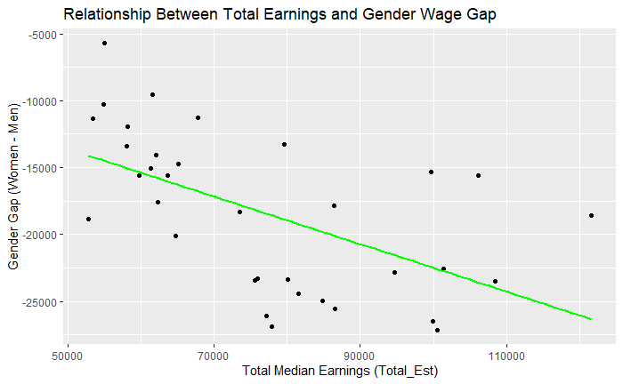

```r
library(ggplot2)

ggplot(df_1, aes(x = Total_Est, y = WM_Gap)) +
  geom_point() +
  geom_smooth(method = "lm", se = FALSE, color = "green") +
  labs(
    title = "Relationship Between Total Earnings and Gender Wage Gap",
    x = "Total Median Earnings (Total_Est)",
    y = "Gender Gap (Women - Men)"
  )
```

A scatterplot with a fitted regression line was created to demonstratethe downward trend between total earnings and the gender wage gap. The plot shows that degree fields with salaries above approximately $90,000 tend to have much larger negative wage gaps, meanwhile lower-paying fields cluster closer to zero, reflecting narrower gaps.

```r
sTEM_Field_Stat <- tibble::tibble(
  Measure = c("Average Earnings of Women",
    "Average Earnings of Men",
    "Difference (Women - Men)",
    "Women Earnings (% of Men)"
    ),
  Value = c(round(mean(Science_Eng$Women_Est)),
    round(mean(Science_Eng$Men_Est)),
    round(mean(Science_Eng$Women_Est - Science_Eng$Men_Est)),
    percent(mean(Science_Eng$Women_Est) / mean(Science_Eng$Men_Est))
  )
)
sTEM_Field_Stat
```

| Measure | Value |
| --- | --- |
| Average Earnings of Women | 78628 |
| Average Earnings of Men | 99106 |
| Difference (Women - Men) | -20478 |
| Women Earnings (% of Men) | 79% |

```r
Business_Field_Stat <- tibble::tibble(
  Measure = c("Average Earnings of Women",
    "Average Earnings of Men",
    "Difference (Women - Men)",
    "Women Earnings (% of Men)"
    ),
  Value = c(round(mean(Business$Women_Est)),
    round(mean(Business$Men_Est)),
    round(mean(Business$Women_Est - Business$Men_Est)),percent(mean(Business$Women_Est) / mean(Business$Men_Est))
  )
)
Business_Field_Stat
```

| Measure | Value |
| --- | --- |
| Average Earnings of Women | 69378 |
| Average Earnings of Men | 93998 |
| Difference (Women - Men) | -24620 |
| Women Earnings (% of Men) | 74% |

```r
Edu_Field_Stat <- tibble::tibble(
  Measure = c("Average Earnings of Women",
    "Average Earnings of Men",
    "Difference (Women - Men)",
    "Women Earnings (% of Men)"
    ),
  Value = c(
    round(mean(Education$Women_Est)),
    round(mean(Education$Men_Est)),
    round(mean(Education$Women_Est - Education$Men_Est)),
    percent(mean(Education$Women_Est) / mean(Education$Men_Est))
  )
)
Edu_Field_Stat
```

| Measure | Value |
| --- | --- |
| Average Earnings of Women | 54567 |
| Average Earnings of Men | 66453 |
| Difference (Women - Men) | -11887 |
| Women Earnings (% of Men) | 82% |

```r
Art_Hum_Other_Stat <- tibble::tibble(
  Measure = c("Average Earnings of Women",
    "Average Earnings of Men",
    "Difference (Women - Men)",
    "Women Earnings (% of Men)"
    ),
  Value = c(
    round(mean(Art_Hum_Other$Women_Est)),
    round(mean(Art_Hum_Other$Men_Est)),
    round(mean(Art_Hum_Other$Women_Est - Art_Hum_Other$Men_Est)),
    percent(mean(Art_Hum_Other$Women_Est) / mean(Art_Hum_Other$Men_Est))
  )
)
Art_Hum_Other_Stat
```

| Measure | Value |
| --- | --- |
| Average Earnings of Women | 56308 |
| Average Earnings of Men | 70357 |
| Difference (Women - Men) | -14049 |
| Women Earnings (% of Men) | 80% |

```r
Macro_Stats<- tibble::tibble(
  Measure = c("Average Earnings of Women",
              "Average Earnings of Men","Difference (Women - Men)", "Women Earnings (% of Men)"
    ),
  Value = c(round(mean(df_1$Women_Est)),
    round(mean(df_1$Men_Est)),
    round(mean(df_1$Women_Est - df_1$Men_Est)),
    percent(mean(df_1$Women_Est) / mean(df_1$Men_Est))
  )
)
Macro_Stats
```

| Measure | Value |
| --- | --- |
| Average Earnings of Women | 67651 |
| Average Earnings of Men | 86022 |
| Difference (Women - Men) | -18371 |
| Women Earnings (% of Men) | 79% |

Overall, women earn an average of $67,651, while men earn $86,022, meaning women earn only 79% of men’s earnings which is a gap of –$18,371. This clear, consistent difference across all majors confirms that a gender wage gap does exist, even when averaging across the entire dataset.

## Results

The descriptive statistics, visualizations, and correlation analysis consistently reveal that the gender wage gap not only exists across all bachelor’s degree majors and fields but grows larger as the salary of the major increases. The gap appears most noticeable in the highest-earning areas such as Science & Engineering and Business, where women earn between 74%–79% of men’s salaries. In contrast, lower-earning fields such as Education and Arts/Humanities show smaller gaps, with women earning 80%–82% of men’s earnings.Overall educated women received approximately 79% of what their men counterparts earned in 2022.

A correlation of –0.56 between total median earnings and the wage gap further demonstrates that disparities increase as the earning potential of a major rises. Together, these findings provide strong evidence that the gender wage gap is both real and systematically linked to the salary level of the field. Nevertheless, there are limitations that restrict the strength of these conclusions.

### Limitations

Although the dataset provides valuable information about gender differences in median annual earnings by field of bachelor’s degree, there several limitations. First, the dataset does not include years of work experience, even though experience significantly affects earnings and may differ between men and women.The method of data collection is also unknown- whether the earnings were self-reported, employer-reported, or obtained through government records such as tax records or social security. The dataset also lacks information on hours worked, meaning differences between full-time and part-time employment cannot be accounted for. Furthermore, only two gender categories are reported, excluding non-binary or other gender identities. The dataset records only the first bachelor’s degree major, even though many individuals pursue graduate degrees or additional credentials that influence salary outcomes.The dataset reflects earnings from 2022, it represents only a single point in time; wage patterns may have shifted since then, meaning the gender gaps observed here could have either narrowed or widened in more recent years. Finally, the data assume that individuals are employed in fields related to their degree, which is not always the case. For example, an art major may be working in education or business.T These limitations should be considered carefully, as they represent factors outside the data’s control that may contribute to the wage differences observed.

### Data Cleaning Process

```r
df_0 <- read_excel("Tab2_FOD.xlsx")
df_0
```

| Table 2: Median Annual Earnings for Field of Bachelor's Degree for First Major by Sex in 2022 | ...2 | ...3 | ...4 | ...5 | ...6 | ...7 | ...8 | ...9 |
| --- | --- | --- | --- | --- | --- | --- | --- | --- |
| Field of Degree | Total Population | NA | Men | NA | Women | NA | Women's Earnings as a Percentage of Men's Earnings | NA |
| NA | Estimate | MOE | Estimate | MOE | Estimate | MOE | Estimate | MOE |
| Population 25 to 64 with a Bachelor's Degree or Higher with earnings | 74150 | 165.7 | 89300 | 358.2 | 63230 | 131.9 | 70.8 | 0.3 |
| Science and Engineering Degrees | NA | NA | NA | NA | NA | NA | NA | NA |
| Computer Science | 108500 | 1597 | 115500 | 1749 | 91990 | 2082 | 79.599999999999994 | 2.2000000000000002 |
| Engineering | 100600 | 1031 | 103300 | 1409 | 76160 | 6168 | 73.7 | 6.1 |
| Civil Engineering | 99660 | 1702 | 101900 | 1048 | 86590 | 3583 | 85 | 3.6 |
| Electrical Engineering | 121600 | 1239 | 123800 | 1203 | 105200 | 2719 | 85 | 2.2999999999999998 |
| Mechanical Engineering | 106200 | 957.2 | 108000 | 1584 | 92380 | 3243 | 85.5 | 3.3 |
| Mathmatics | 86560 | 1476 | 99050 | 3109 | 73500 | 1814 | 74.2 | 3 |

[output cut: 34 more lines]

```r
df_1 <- read_excel("Tab2_FOD.xlsx", skip = 4)
df_1
```

| Science and Engineering Degrees | ...2 | ...3 | ...4 | ...5 | ...6 | ...7 | ...8 | ...9 |
| --- | --- | --- | --- | --- | --- | --- | --- | --- |
| Computer Science | 108500 | 1597.0 | 115500 | 1749.0 | 91990 | 2082.0 | 79.6 | 2.2 |
| Engineering | 100600 | 1031.0 | 103300 | 1409.0 | 76160 | 6168.0 | 73.7 | 6.1 |
| Civil Engineering | 99660 | 1702.0 | 101900 | 1048.0 | 86590 | 3583.0 | 85.0 | 3.6 |
| Electrical Engineering | 121600 | 1239.0 | 123800 | 1203.0 | 105200 | 2719.0 | 85.0 | 2.3 |
| Mechanical Engineering | 106200 | 957.2 | 108000 | 1584.0 | 92380 | 3243.0 | 85.5 | 3.3 |
| Mathmatics | 86560 | 1476.0 | 99050 | 3109.0 | 73500 | 1814.0 | 74.2 | 3.0 |
| Biology | 81550 | 706.8 | 96620 | 2112.0 | 72200 | 961.4 | 74.7 | 1.9 |
| Chemistry | 94680 | 2114.0 | 103000 | 1802.0 | 80180 | 3164.0 | 77.8 | 3.4 |
| Psychology | 62270 | 488.2 | 76090 | 1168.0 | 58490 | 805.7 | 76.9 | 1.6 |
| Economics | 101400 | 916.1 | 107300 | 1277.0 | 84750 | 2198.0 | 79.0 | 2.3 |

[output cut: 30 more lines]

```r
colnames(df_1) <- c(
  "Bachelor's Degree",
  "Total_Est", "Total_MOE",
  "Men_Est", "Men_MOE",
  "Women_Est", "Women_MOE",
  "Women_PE", "Women_PM"
)
```

```r
df_1 <- df_1[1:37, ] # removing the written data at the bottom of dataframe and subsetting to
```

```r
df_0 %>% filter(!complete.cases(.))
```

| Table 2: Median Annual Earnings for Field of Bachelor's Degree for First Major by Sex in 2022 | ...2 | ...3 | ...4 | ...5 | ...6 | ...7 | ...8 | ...9 |
| --- | --- | --- | --- | --- | --- | --- | --- | --- |
| Field of Degree | Total Population | NA | Men | NA | Women | NA | Women's Earnings as a Percentage of Men's Earnings | NA |
| NA | Estimate | MOE | Estimate | MOE | Estimate | MOE | Estimate | MOE |
| Science and Engineering Degrees | NA | NA | NA | NA | NA | NA | NA | NA |
| Business Degrees | NA | NA | NA | NA | NA | NA | NA | NA |
| Education Degrees | NA | NA | NA | NA | NA | NA | NA | NA |
| Arts, Humanities and Other Degrees | NA | NA | NA | NA | NA | NA | NA | NA |
| Source: U.S. Census Bureau, 2022 American Community Survey, 1-year estimates. For more information, refer to . | NA | NA | NA | NA | NA | NA | NA | NA |
| The Census Bureau has reviewed this data product to ensure appropriate access, use, and disclosure avoidance protection of the confidential source data used to produce this product (Data Management Sy… | NA | NA | NA | NA | NA | NA | NA | NA |
| Note: 1. Science and Engineering related fields are included within the "other science and engineering degrees" category. | NA | NA | NA | NA | NA | NA | NA | NA |

```r
df_1 <- na.omit(df_1)
df_1$WM_Gap <- df_1$Women_Est - df_1$Men_Est
```

Removed rows with NA values. Created a column with remaining rows to represent the wage gap.

```r
Science_Eng <- df_1[1:14, ]
Business <- df_1[15:20, ]
Education<- df_1[21:23, ]
Art_Hum_Other <- df_1[24:34, ]
```

Created subsets of the data to make comparisons between field statistics.